# Diamonds quality

In this data challenge we explore the qualities of diamonds and their association with price using the `ggplot2::diamonds` dataset:

1. First of all, observe that low quality diamonds (with respect to cut, color and clarity) are more expensive.
2. Using models, find an explanation and solve the apparent paradox.

Recall that:

- best cut is Ideal, worst is Fair
- best color is D, worst is J
- best clarity is IF, worst is I1

```r
library(dplyr)
library(ggplot2)

diamonds
```

```
## # A tibble: 53,940 × 10
##    carat cut       color clarity depth table price     x     y     z
##    <dbl> <ord>     <ord> <ord>   <dbl> <dbl> <int> <dbl> <dbl> <dbl>
##  1  0.23 Ideal     E     SI2      61.5    55   326  3.95  3.98  2.43
##  2  0.21 Premium   E     SI1      59.8    61   326  3.89  3.84  2.31
##  3  0.23 Good      E     VS1      56.9    65   327  4.05  4.07  2.31
##  4  0.29 Premium   I     VS2      62.4    58   334  4.2   4.23  2.63
##  5  0.31 Good      J     SI2      63.3    58   335  4.34  4.35  2.75
##  6  0.24 Very Good J     VVS2     62.8    57   336  3.94  3.96  2.48
##  7  0.24 Very Good I     VVS1     62.3    57   336  3.95  3.98  2.47
##  8  0.26 Very Good H     SI1      61.9    55   337  4.07  4.11  2.53
##  9  0.22 Fair      E     VS2      65.1    61   337  3.87  3.78  2.49
## 10  0.23 Very Good H     VS1      59.4    61   338  4     4.05  2.39
## # ℹ 53,930 more rows
```

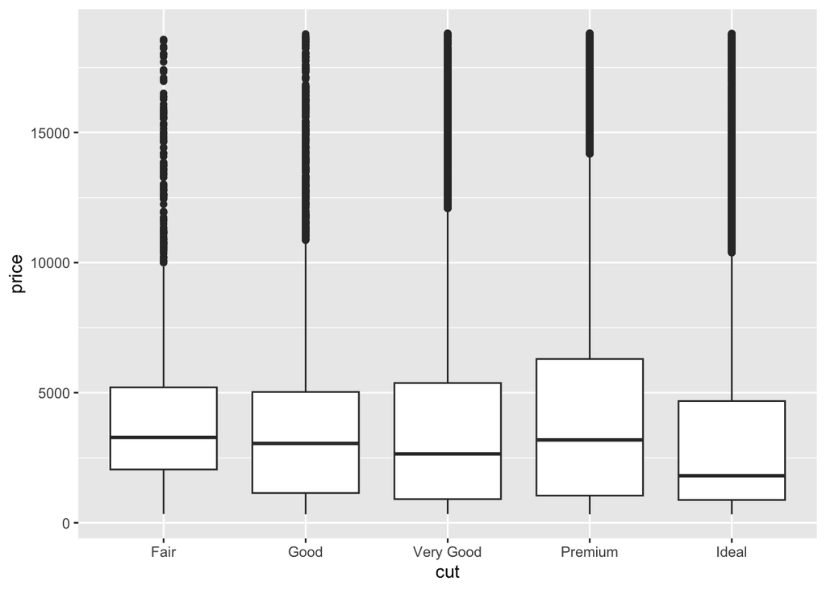

```r
ggplot(diamonds, aes(cut, price)) +
  geom_boxplot()
```

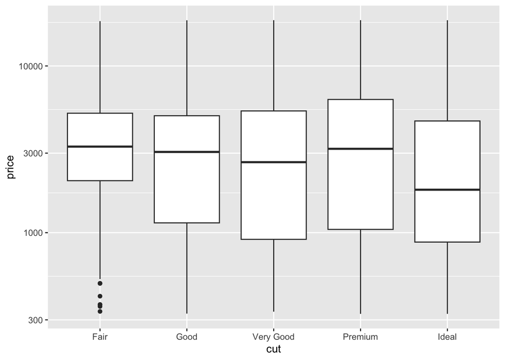

```r
ggplot(diamonds, aes(cut, price)) +
  geom_boxplot() +
  scale_y_log10()
```

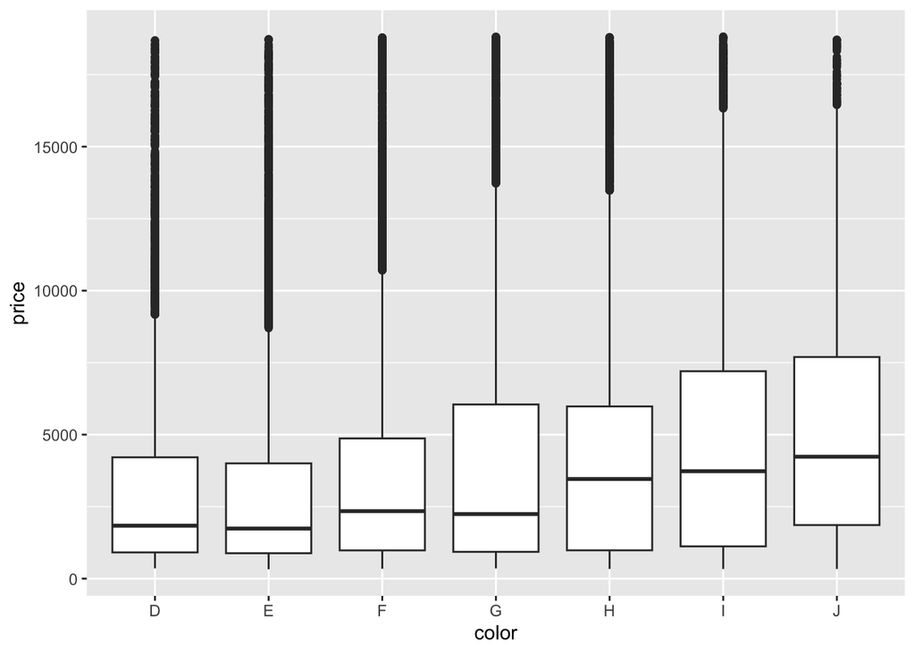

```r
ggplot(diamonds, aes(color, price)) +
  geom_boxplot()
```

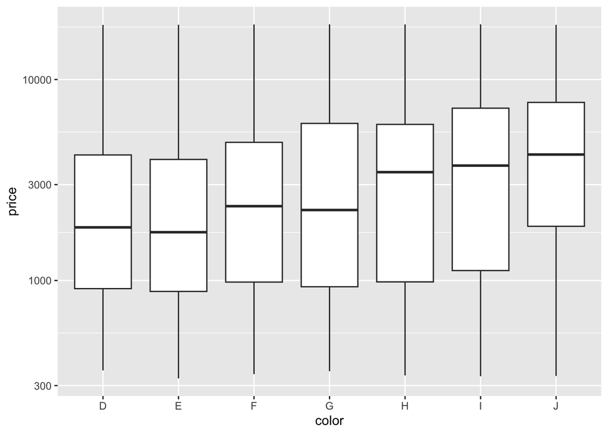

```r
ggplot(diamonds, aes(color, price)) +
  geom_boxplot() +
  scale_y_log10()
```

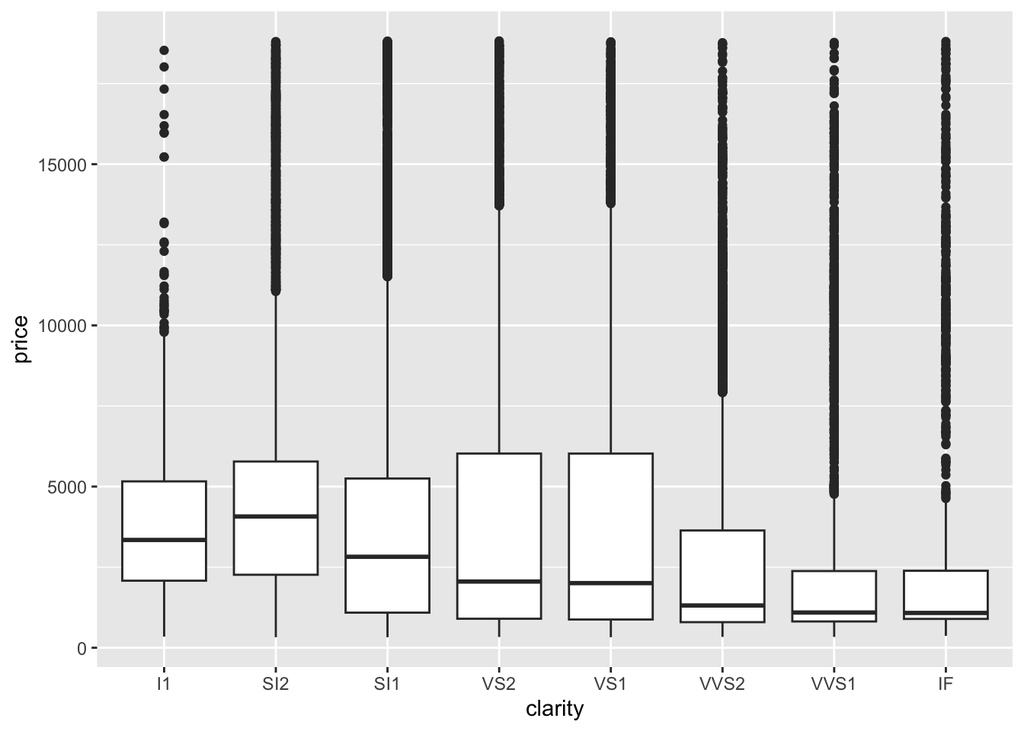

```r
ggplot(diamonds, aes(clarity, price)) +
  geom_boxplot()
```

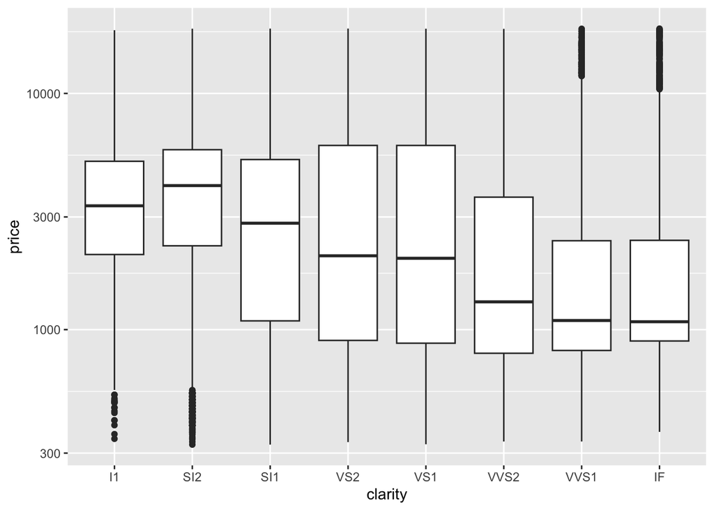

```r
ggplot(diamonds, aes(clarity, price)) +
  geom_boxplot() +
  scale_y_log10()
```

```r
diamonds |>
  group_by(cut) |>
  summarise(n = n(), mean_price = mean(price), median_price = median(price))
```

```
## # A tibble: 5 × 4
##   cut           n mean_price median_price
##   <ord>     <int>      <dbl>        <dbl>
## 1 Fair       1610      4359.        3282
## 2 Good       4906      3929.        3050.
## 3 Very Good 12082      3982.        2648
## 4 Premium   13791      4584.        3185
## 5 Ideal     21551      3458.        1810
```

```r
diamonds |>
  group_by(color) |>
  summarise(n = n(), mean_price = mean(price), median_price = median(price))
```

```
## # A tibble: 7 × 4
##   color     n mean_price median_price
##   <ord> <int>      <dbl>        <dbl>
## 1 D      6775      3170.        1838
## 2 E      9797      3077.        1739
## 3 F      9542      3725.        2344.
## 4 G     11292      3999.        2242
## 5 H      8304      4487.        3460
## 6 I      5422      5092.        3730
## 7 J      2808      5324.        4234
```

```r
diamonds |>
  group_by(clarity) |>
  summarise(n = n(), mean_price = mean(price), median_price = median(price))
```

```
## # A tibble: 8 × 4
##   clarity     n mean_price median_price
##   <ord>   <int>      <dbl>        <dbl>
## 1 I1        741      3924.         3344
## 2 SI2      9194      5063.         4072
## 3 SI1     13065      3996.         2822
## 4 VS2     12258      3925.         2054
## 5 VS1      8171      3839.         2005
## 6 VVS2     5066      3284.         1311
## 7 VVS1     3655      2523.         1093
## 8 IF       1790      2865.         1080
```

# I risultati ottenuti confermano l’affermazione iniziale, ovvero che i diamanti di qualità inferiore tendono a costare di più.

# Per il colore, il prezzo mediano cresce passando dal migliore (D, circa 1.800 dollari) al peggiore (J, circa 4.200). # Per la purezza, le classi migliori (VVS1 e IF) hanno i prezzi mediani più bassi (circa 1.100 dollari), mentre quelle peggiori (SI2 e I1) hanno i più alti (circa 3.300–4.000).

# Per il taglio la tendenza è meno regolare, ma il taglio migliore, Ideal, ha il prezzo mediano più basso (circa 1.800), mentre Fair, il peggiore, sta attorno a 3.300.

# Inoltre, si può osservare che in tutte e tre le categorie i prezzi mostrano una distribuzione molto asimmetrica, con molti valori elevati sopra i box.

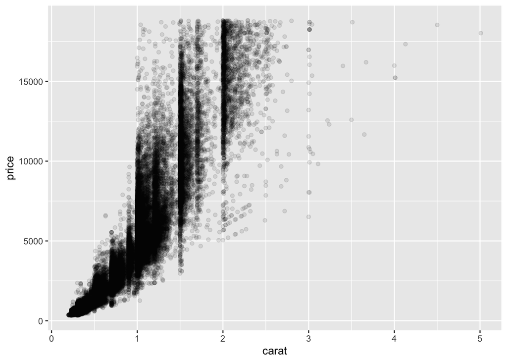

```r
ggplot(diamonds, aes(carat, price)) +
  geom_point(alpha = 1/10)
```

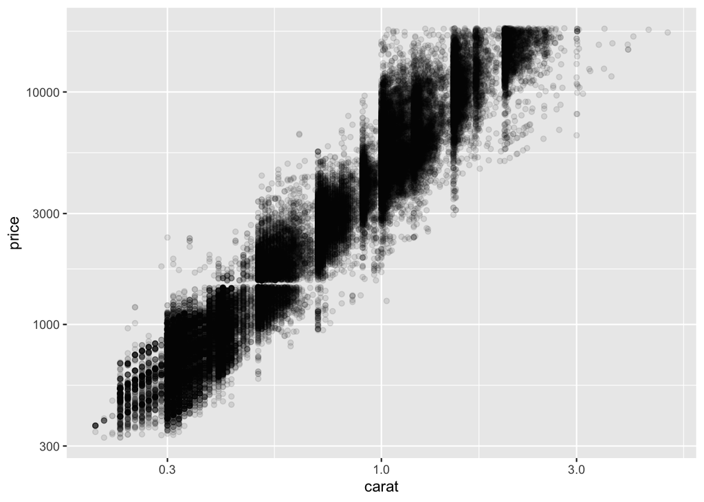

```r
ggplot(diamonds, aes(carat, price)) +
  geom_point(alpha = 1/10) +
  scale_x_log10() +
  scale_y_log10()
```

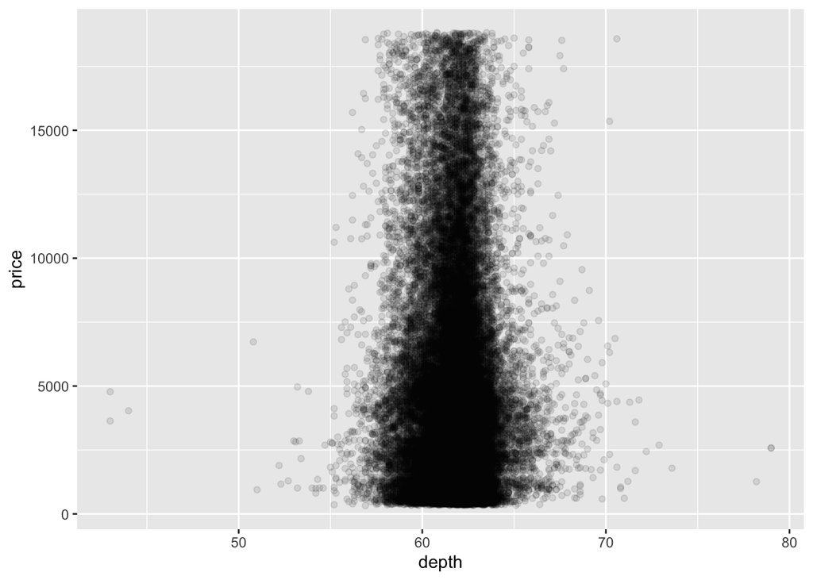

```r
ggplot(diamonds, aes(depth, price)) +
  geom_point(alpha = 1/10)
```

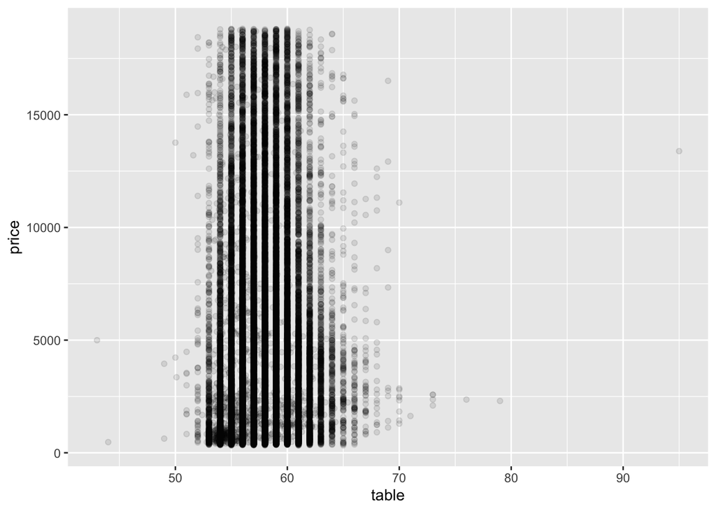

```r
ggplot(diamonds, aes(table, price)) +
  geom_point(alpha = 1/10)
```

```r
diamonds |>
  summarise(
    cor_carat = cor(price, carat),
    cor_depth = cor(price, depth),
    cor_table = cor(price, table)
  )
```

```
## # A tibble: 1 × 3
##   cor_carat cor_depth cor_table
##       <dbl>     <dbl>     <dbl>
## 1     0.922   -0.0106     0.127
```

# Per capire cosa potesse alterare in questo modo i prezzi ho cercato sul dataset le variabili restanti, quindi, “carat”, “depth” e “table” (non ho considerato x,y,z in quanto indicano la dimensione fisica del diamante e quindi, strettamente legate alla variabile del carato, che ne indica il peso).

# Per ciascuna ho tracciato un grafico, per verificare l’andamento del prezzo rispetto alla variabile e ho calcolato il coefficiente di correlazione.

# Per il peso ho usato anche la scala logaritmica sui due assi, che rende la relazione quasi lineare.

# I risultati sono esplicativi: il prezzo è fortemente correlato al peso (correlazione 0,92), mentre lo è pochissimo a depth (−0,01) e debolmente a table (0,13).

# Il pes, quindi, è l’unica variabile che altera in modo considerevole il prezzo ed è la candidata naturale a spiegare il paradosso: se i diamanti di qualità inferiore fossero mediamente più pesanti, risulterebbero più costosi pur valendo meno a parità di peso.

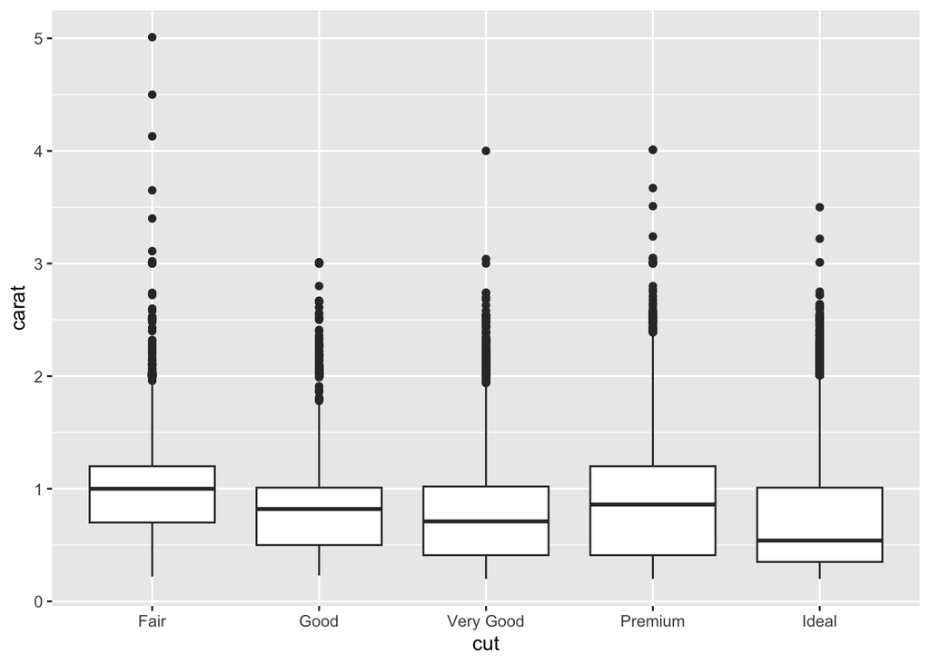

```r
ggplot(diamonds, aes(cut, carat)) +
  geom_boxplot()
```

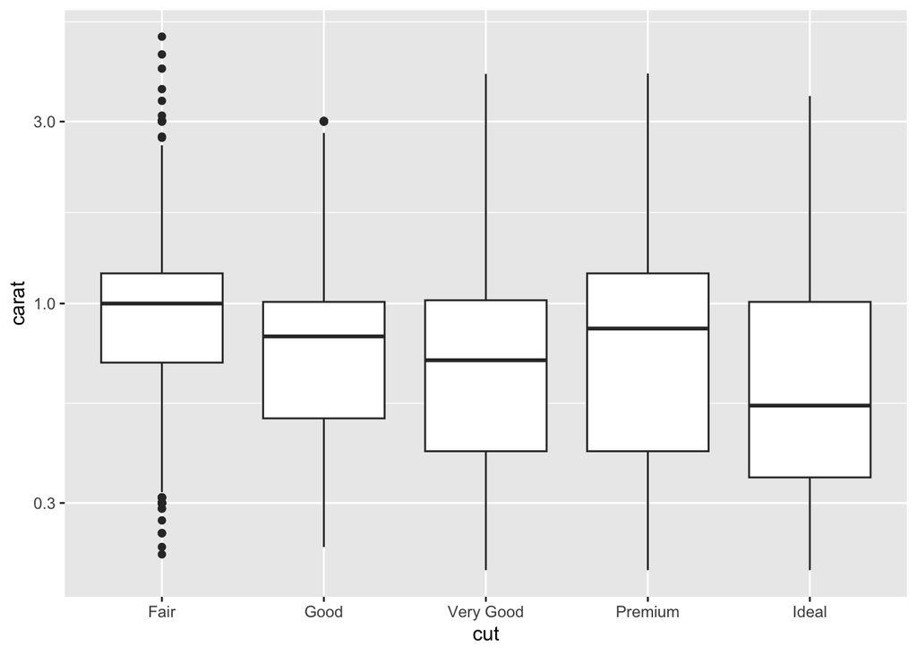

```r
ggplot(diamonds, aes(cut, carat)) +
  geom_boxplot() +
  scale_y_log10()
```

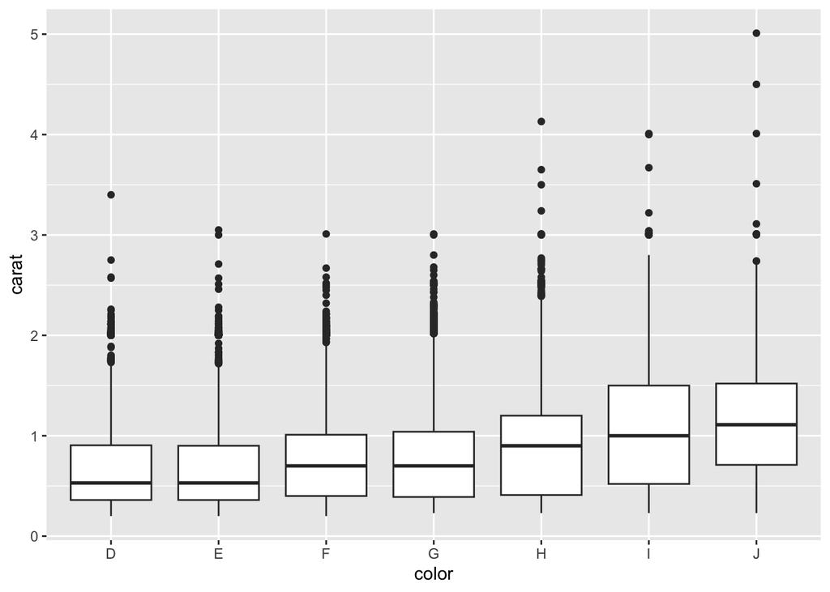

```r
ggplot(diamonds, aes(color, carat)) +
  geom_boxplot()
```

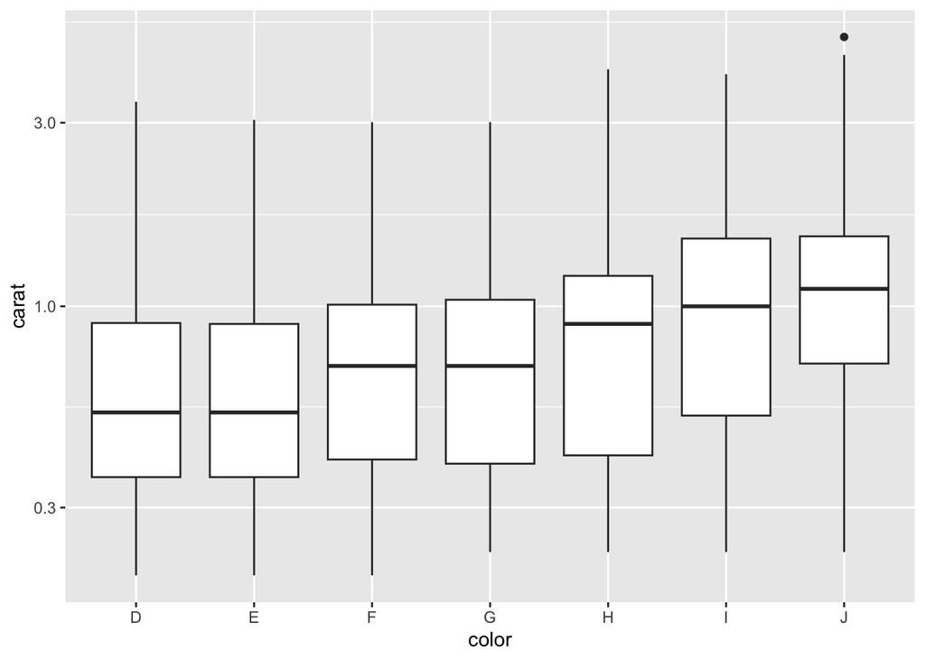

```r
ggplot(diamonds, aes(color, carat)) +
  geom_boxplot() +
  scale_y_log10()
```

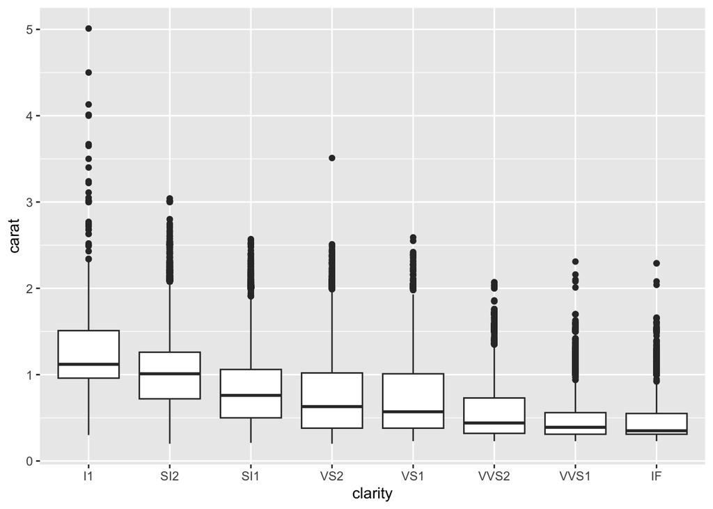

```r
ggplot(diamonds, aes(clarity, carat)) +
  geom_boxplot()
```

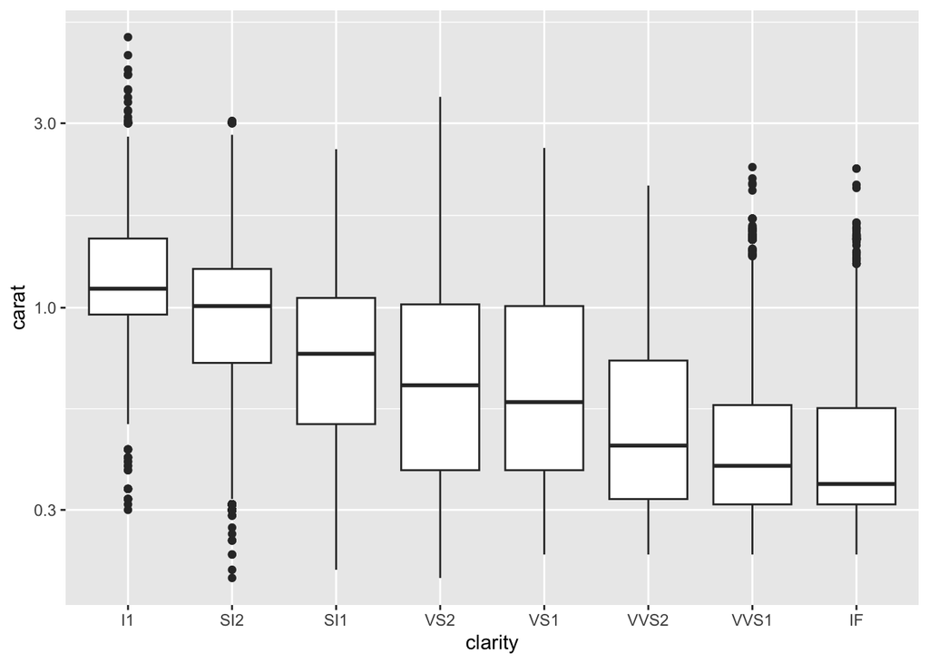

```r
ggplot(diamonds, aes(clarity, carat)) +
  geom_boxplot() +
  scale_y_log10()
```

# Si può osservare come il peso mediano dei diamanti cresce al peggiorare della qualità: i tagli peggiori (Fair), i colori peggiori (I e J) e le purezze peggiori (I1 e SI2) sono mediamente più pesanti dei migliori. Poiché il prezzo dipende fortemente dal peso, i diamanti di qualità inferiore risultano più costosi proprio perché più grandi.

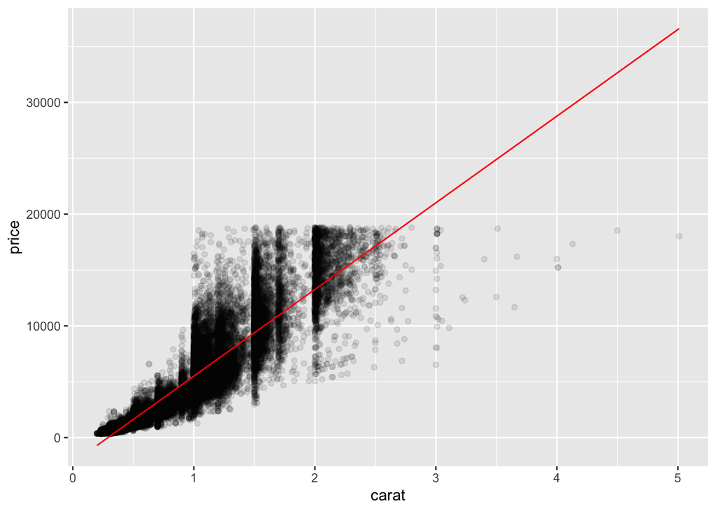

```r
library(modelr)

mod <- lm(price ~ carat, data = diamonds)

diamonds_mod <- diamonds |>
  add_predictions(mod)

diamonds_mod |>
  ggplot(aes(carat, price)) +
  geom_point(alpha = 1/10) +
  geom_line(aes(y = pred), colour = "red")
```